**Lab 070 · six live operations, fresh fitted baselines and a frozen intervention**

The preview is read-only. Run the notebook in Colab or Jupyter. Default uses CPU and archived pretrained probabilities.

# Lab 070 · Defend a foundation-model baseline

Lesson · Reference · Author evidence · Reproduction

Implement six evaluation operations and run **fresh corrected TabM-mini and XGBoost fits** on five real numeric tables, three downstream seeds and two candidates. Audit all 105 historical prediction sets, then produce a corrected seven-arm hybrid comparison and a fixed-model feature-erasure test. The historical TabM variant is retained in a separate diagnostic and is not the corrected model. The core skill is the comparison procedure; the corrected model and its trainer are fully visible PROVIDED code.

**Environment:** bounded CPU training, with no pretrained checkpoint download on the default path. Colab bootstrap supplies code and data access; exact public data snapshots are bundled and verified before use. The entire recap below is self-contained. **Workflow:** attempt retrieval and prediction; implement the TODO; diagnose with CHECK; execute the live experiment; then defend the EXIT. Figures and tables labeled author evidence are not your current kernel's results. Full original pretraining/benchmark reproduction is INCOMPARABLE/NOT_RUN.

### Running on Google Colab?

Colab opens only this single file, so the course package (`relkit`) and the lab dependencies (xgboost, lightgbm, catboost, …) are **not** present by default. The cell below fixes that: on Colab it shallow-clones the course repo, installs `requirements-labs.txt`, and switches into `labs/` so `relkit` imports and the data cache resolve. **On a local venv or your own Jupyter it does nothing — just run it and continue.**

```python
# @colab-bootstrap — PROVIDED. Makes the lab self-sufficient on Google Colab; a no-op elsewhere.
import os, sys

if "google.colab" in sys.modules:
    if not os.path.isdir("/content/relational"):
        !git clone --depth 1 https://github.com/Avistian/relational.git /content/relational
    %pip install -q -r /content/relational/requirements-labs.txt
    os.chdir("/content/relational/labs")
    print("Colab ready — working dir:", os.getcwd())
else:
    print("Not on Colab — using the local environment as-is.")
```

## Carry a defensible tabular baseline into relational research

The sequence has built three kinds of knowledge: how a model computes, what information it may use, and where its deployment contract can fail. This checkpoint connects them into one model decision. The output should be a saved, replayable procedure with measured limits—not a preference for a family name.

## The checkpoint is a decision procedure

> **In plain terms.** A model's *name* proves nothing. What defends a result is the whole *procedure* around it: what data was available, how it was prepared, how the winner was chosen, and how it was scored. This checkpoint is about building and defending that procedure.

Imagine defending a relational model to a skeptical reviewer. You have a new neural architecture, a convincing diagram and a higher score than a tree baseline. The reviewer asks three questions. Which tree configurations did you try? Did the pretrained baseline see the same legal history? Did you choose your best experiment after looking at test labels? A **procedure** answers those questions: data availability → preparation → candidate fitting → validation selection → frozen prediction → evaluation. A model name alone cannot.

**What this checkpoint trains.** Your skill here is to construct and defend that procedure. You will audit an existing seven-arm experiment. You will train a corrected neural baseline on exactly its rows. You will perform a feature-loss intervention with frozen fitted models. The outcome is an executable argument about a particular prediction task, including a result that could change your recommendation. It is preparation for relational research, where information cutoffs and target identity matter at least as much as architecture.

**Reading route.** Start with the [TabPFN-3 report, §§2.1–2.4 and Appendix C](https://arxiv.org/html/2605.13986v1#S2), then compare [TabICLv2 §3 and Appendix A](https://arxiv.org/html/2602.11139v1#S3). Read the first report's Appendices E.2–E.3 before interpreting a leaderboard. This lesson teaches their mechanisms and evaluation distinctions; it does not reproduce either report's benchmark.

## Freeze what a prediction means

> **In plain terms.** Pin down what one prediction *means* — which row, which class counts as "1," which rows train, validate and test — before you compute anything. A single scalar score can hide a reversed column or a missing row.

**The prediction unit.** The prediction unit here is a row in a small binary table. A target is encoded as 0 or 1, and every arm returns **P(y=1)** in the same original test-row order. This convention is not interchangeable with “probability of the undesirable outcome.” In sklearn's breast-cancer table, class 1 means **benign**. The lab reconstructs the semantic label map from each raw source instead of inferring it from a model name.

**What a split is.** A **split** partitions row IDs into train, validation and test. Training rows fit imputation statistics and model parameters. Validation rows select candidates and neural epochs. Test labels score the final choice. The local design samples at most 600 original rows without consulting labels, using sampling seed 70. It stratifies a 20% test partition with seed 70, then takes 25% of the remaining rows for validation using seed 71. Thus the approximate proportions are 60/20/20. Stratification uses targets to construct balanced partitions; those targets are not available to the model as query features.

| Dataset | Source | Original rows | Used rows | Features | Train / validation / test |
| --- | --- | --- | --- | --- | --- |
| diabetes | OpenML 37 | 768 | 600 | 8 | 360 / 120 / 120 |
| blood_transfusion | OpenML 1464 | 748 | 600 | 4 | 360 / 120 / 120 |
| kc1 | OpenML 1067 | 2,109 | 600 | 21 | 360 / 120 / 120 |
| phoneme | OpenML 1489 | 5,404 | 600 | 5 | 360 / 120 / 120 |
| breast_cancer | sklearn WDBC | 569 | 569 | 30 | 341 / 114 / 114 |

All five tasks are numeric binary classification. This is a useful small CPU comparison; it supplies no local evidence about mixed categorical schemas, regression, time-based splits or million-row inference. Median imputation is fitted on training rows only. Corrected TabM additionally fits a training-only StandardScaler. Pretrained wrappers retain their own released transformations after the common imputation. **Common information access does not require identical model-specific preprocessing.** Requiring every learner to use another model's preferred scaling could itself weaken a baseline.

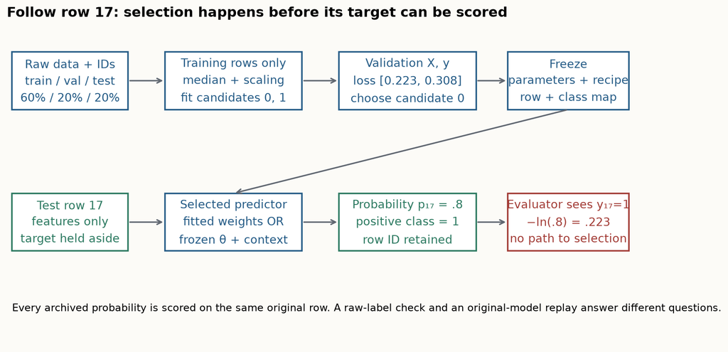

Illustrative row 17: train-only preprocessing, validation candidate selection, then frozen test prediction and scoring. The test label has no arrow back to selection. Full-size figure.

**Connecting the ideas.** Freezing the prediction question is the first step. Next freeze the object that answers it: package, checkpoint, context, transformations and aggregation policy. Otherwise two runs with the same family name may implement different functions.

**Connecting the ideas.** Once identities are fixed, compare the actual information routes. Trees and TabM store target-task learning primarily in fitted parameters; PFNs also consume labeled context at prediction. That difference explains what must be saved and where computation is paid.

### The final checkpoint: choose a defensible fitted system

**Trace before reading:** What must be saved to replay a PFN prediction that is not contained in its checkpoint?

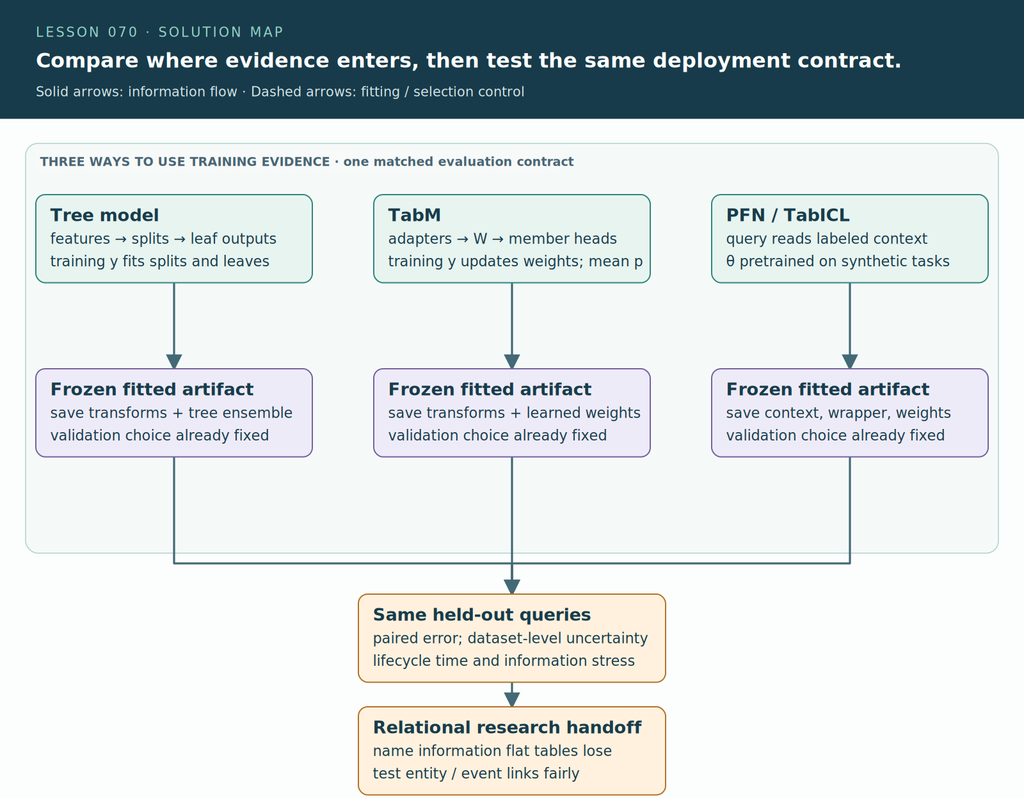

**How the parts work together:** Save context IDs and labels, preprocessing, feature/class order, view policy and checkpoint identity. Compare this full procedure with the complete tree and TabM artifacts, using the same held-out rows and declared selection budget.

**Pictured scope:** Decision architecture for the lesson’s measured comparison. Family diagrams summarize information routes; exact checkpoint and wrapper identities remain in the lesson evidence ledger.

Full-size vector diagram. Scroll on narrow screens to keep labels legible.

**Text route: components and connections**

1. **Tree model**: features → splits → leaf outputs; training y fits splits and leaves. Connects to Frozen fitted artifact.
2. **Frozen fitted artifact**: save transforms + tree ensemble; validation choice already fixed. Connects to Same held-out queries.
3. **TabM**: adapters → W → member heads; training y updates weights; mean p. Connects to Frozen fitted artifact.
4. **Frozen fitted artifact**: save transforms + learned weights; validation choice already fixed. Connects to Same held-out queries.
5. **PFN / TabICL**: query reads labeled context; θ pretrained on synthetic tasks. Connects to Frozen fitted artifact.
6. **Frozen fitted artifact**: save context, wrapper, weights; validation choice already fixed. Connects to Same held-out queries.
7. **Same held-out queries**: paired error; dataset-level uncertainty; lifecycle time and information stress. Connects to Relational research handoff.
8. **Relational research handoff**: name information flat tables lose; test entity / event links fairly.

**Worked trace of one test ID.** Follow one test ID through the diagram. Its features can enter a frozen predictor, while its target enters only the loss function. The validation arrow selects a candidate; it never points backward from the test score. A serialized artifact should let another evaluator recover the row order, class semantics, selected candidate and probabilities. A scalar score by itself cannot expose a missing row or reversed probability column.

**Three checks, three different claims.** There are three related but different checks. Reconstructing loss from saved probabilities verifies arithmetic. Matching raw source labels to saved test IDs verifies local alignment. Reexecuting the pinned original predictor verifies that the named operator produces those probabilities. None alone proves absence of every historical development leak. In particular, development-set overlap with public benchmark tasks must be audited separately from the local split.

## A checkpoint identity is larger than its family name

> **In plain terms.** "TabPFN" or "TabICL" names a *family*, not a specific trained model. Two checkpoints under one family name can behave differently, so every arm is pinned to an exact wheel, revision and digest.

**The archive and the repair.** The original archive has seven arms × five datasets × three downstream seeds = **105 selected results**. It remains unchanged. The primary repaired comparison also has seven arms: it replaces the legacy TabM result with 15 **freshly fitted TabM-mini-v2** results and keeps the six valid archived arms. A separately labeled eight-arm diagnostic retains both TabM implementations to expose the effect of the repair. Ranks belong to their declared pool; they are recomputed for each pool.

| Arm in the primary comparison | Operator identity | Evidence origin |
| --- | --- | --- |
| XGBoost | Recorded historical version, 100 trees; validation selects depth 3 or 6 | Archived probabilities |
| TabM-mini-v2 | Corrected independent numeric implementation; k=8, width 64, depth 3 | Fresh fits |
| TabPFN-v2 | tabpfn 2.0.9; Nature classifier `f65a3568…` | Archived one-estimator inference |
| TabICL-v1.1 | tabicl 0.1.4; May v1.1 checkpoint `cd0296d7…` | Archived one-estimator inference |
| TabPFN-2.5-synthetic | tabpfn 8.5.0; `v2.5_default-2`, `2d0fbd25…` | Archived one-estimator inference |
| TabPFN-3 | tabpfn 8.5.0; `v3_default`, `d0d865d5…` | Archived one-estimator inference |
| TabICLv2 | tabicl 2.2.0; February 2026 classifier `bdc7dbd5…` | Archived one-estimator inference |

The complete filenames, immutable model revisions, full SHA256 digests, package wheels and source files are in the source ledger. A package can support several learned models. The TabICL-v1.1 arm here is **not** the earlier February TabICL checkpoint studied in lesson 066. Likewise, synthetic TabPFN-2.5 is not Real-TabPFN-2.5, which has an additional real-data training history; the [2.5 report](https://arxiv.org/html/2511.08667v1) distinguishes them explicitly. Comparing either one's number under the other's name would change the scientific claim.

**What a downstream seed does and does not change.** A downstream seed means different things across arms. It changes neural initialization and minibatch order for TabM. It changes subsampling in XGBoost. It can change permutations and transformations around a fixed pretrained network. Three such seeds do not create three independently pretrained TabPFNs. The fixed split also leaves split uncertainty unmeasured.

> **Scope check.** The legacy arm called `TabM-mini` had an extra first-layer output adapter, per-member backbone biases and incorrect fan-in initialization. It remains an identifiable historical neural variant, but is not accepted as the paper's mini architecture. Corrected results are versioned, not pasted over old predictions. The fresh XGBoost fits form an additional **replay control** and a paired intervention control; they do not become a second XGBoost opponent in the primary rank table.

## Compare where each architecture spends its work

> **In plain terms.** These models "think" in different places. A tree or TabM stores the task in fitted weights; a pretrained in-context learner keeps a cross-task recipe frozen and reads your labeled rows at inference. Even a no-gradient `fit` can do real work.

No new model is introduced for implementation in this checkpoint. Instead, trace the connected prediction paths you are evaluating. A trained tree or TabM carries a dataset-specific mapping in fitted parameters. A pretrained in-context learner carries a cross-task mapping in frozen parameters and conditions on labeled rows supplied at inference. Its `fit` method need not perform gradient updates to incur substantial work: it can prepare transformations, embeddings or attention caches.

**Corrected TabM-mini.** For a batch X with B rows and F features, expand to B×k×F, multiply by a first trainable member adapter R, and apply shared Linear → ReLU → Dropout blocks. Mini has no output adapter S and uses shared backbone biases. Independent heads return logits B×k×2. During training, average each member's cross-entropy; at inference, average member probabilities. **Worked example.** If two members give P(y=1)=0.9 and 0.1 on a positive row, the training loss is (−ln 0.9−ln 0.1)/2=1.204 nats, while the ensemble prediction is 0.5 with loss 0.693. Averaging logits or training only the averaged prediction changes the computation. This is the [TabM §3.3/§5.1](https://arxiv.org/html/2410.24210v3) distinction the provided model retains.

**Nature TabPFN-v2 and TabPFN-2.5.** Features form grouped tokens alongside a target token. Alternating attention mixes features within rows and rows within feature groups. The feature axis remains present through repeated blocks. For N = C + Q total rows, C context rows and G feature groups, the masked attention-score work contains terms proportional to NG² and GNC, apart from widths and heads. Query rows read context rows, so at fixed C the row-attention term grows linearly with Q. It becomes quadratic in N when context remains a fixed fraction of total rows. The v2 classification network studied in lessons 064/069 has twelve blocks, dimension 192 and six heads. The loaded synthetic 2.5 classifier has 24 blocks, dimension 192, three attention heads and feature groups of size 3; its report additionally describes 64 learned thinking rows. A richer or deeper checkpoint changes learned behavior; a later release number alone does not tell you which inference recipe ran.

**TabICL and TabICLv2.** Column embedding first collects distributional information through a small set of inducing vectors. Row interaction compresses feature tokens into a fixed number of CLS summaries. Dataset-wise attention then acts on row embeddings. This removes the feature multiplier from the later NC attention term, while the column and row stages still cost computation. TabICLv2 adds repeated feature groups, early target-aware embeddings and query-aware attention scaling. Its [Appendix A.3](https://arxiv.org/html/2602.11139v1#A1.SS3) combines mixed-radix target encoding with hierarchical classification beyond the native output classes; that is a different many-class mechanism from TabPFN-3's retrieval head.

**TabPFN-3 connects these ideas.** The report and released 8.5.0 source describe three stages. First, form F circular feature triplets and embed each into dimension 128; targets are added only to training-row cells. Three inducing-attention blocks with 128 inducing vectors summarize distributions. Second, three feature-interaction blocks use four CLS tokens per row. Concatenation yields a 4×128=512-dimensional row embedding. Third, 24 ICL blocks pass information from context rows to query rows. The classifier ends in a six-head retrieval decoder. The source adds RMSNorm, missing-value indicators and checkpoint-specific label embeddings. These are connected components, not interchangeable labels for “attention.”

**Worked example — how a feature group is formed.** Repeated grouping produces F overlapping groups (one anchored at each feature), so the group count equals F, not F divided by three. The TabICLv2 pattern uses offsets (0,1,3) modulo F: with five columns [a,b,c,d,e], the group anchored at a is [a,b,d], and the group anchored at e is [e,a,c]. This example names a group by its first selected feature. Both released implementations index source offsets as (1,2,4) from the output-group index; relative to the first selected feature these are (0,1,3). Thus [a,b,d] is output group 4 in the five-column array, not group 0. Features participate in several local groups. Early target embeddings can distinguish columns with similar marginal distributions but different associations with y. Query labels remain absent: adding a train target to every training cell does not authorize adding the answer to a query cell.

**Attention fading.** Suppose one relevant row has score 2 and n−1 distractors have score 0. Its attention mass is exp(2)/(exp(2)+n−1): approximately 0.451 for n=10 but 0.00734 for n=1,000. So more eligible rows can dilute useful evidence. QASSMax scales query coordinates using a learned function of log context length multiplied by a bounded, query-dependent gate. The gate is 1+tanh(MLP(q)), in (0,2); the base scale is learned too. This does not guarantee that adding context improves accuracy, and it differs from the ordinary 1/√head-dimension factor. The [TabICLv2 §3 ablation motivation](https://arxiv.org/html/2602.11139v1#S3) and released `SoftmaxScalingMLP` make that distinction explicit.

## More supported classes does not invent unseen labels

> **In plain terms.** Giving the model more possible output classes does not let it recognize a class it never saw in context. Extra slots stay empty until real labeled rows fill them.

**How the retrieval decoder votes.** For a query, the TabPFN-3 decoder projects its final embedding to a query vector and the training embeddings to keys. Softmax over training-row similarities produces nonnegative weights α that sum to one. The values are one-hot training labels. For each head, sum α times these values; average heads to get class mass. The implementation then applies a small floor/offset before log conversion, followed by wrapper postprocessing. The following arithmetic isolates the **pre-log voting stage**, not final calibrated package probabilities.

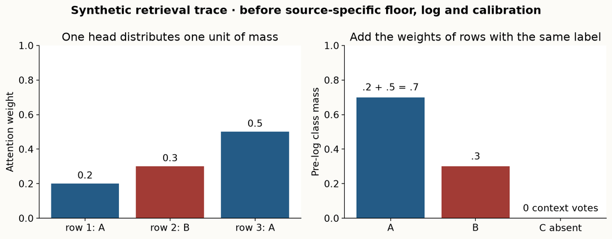

Synthetic pre-log retrieval arithmetic, not final package probabilities: context labels [A,B,A] and weights [.2,.3,.5] produce [.7,.3,0]. Output cardinality does not provide an unseen label with context evidence. Full-size figure.

**Worked example.** Let context labels be [A,B,A] and attention weights [0.2,0.3,0.5]. A receives 0.2+0.5=0.7; B receives 0.3. Adding a possible output label C without any C-labeled context row contributes no C vote. Numerically flooring logits cannot supply semantic evidence about C. This reconnects lesson 069's emerging-class failure with a newer architecture: increasing supported class cardinality and identifying a never-observed class are different tasks.

**The ceiling still exists.** The decoder's parameterization does not require one learned output weight per class. Yet the released checkpoint still has a **160-class ceiling** through its target-embedding and decoder configuration (`max_num_classes=160` in the loaded `v3_default` checkpoint, also used by its wrapper support checks). “Non-parametric in class count” describes the retrieval computation; it does not mean the whole trained system has unlimited classes. See [TabPFN-3 §2.2 and Appendix C](https://arxiv.org/html/2605.13986v1#S2.SS2). The binary local panel cannot measure the claimed many-class advantage.

> **Scope check.** The report's size envelope lists alternative regimes: **1 million rows × 200 features**, **100,000 × 2,000**, or **1,000 × 20,000**. It does not certify 1 million × 20,000. Row streaming computes inducing summaries once over the full context, then reuses those summaries across row chunks. Recomputing an unrelated summary inside each chunk changes the algorithm. The saved 114/120-query CPU calls do not exercise that million-row memory regime.

## Derive the metric and make selection reconstructible

> **In plain terms.** Define the loss precisely, then make winner selection reproducible: another person should be able to recompute every validation loss and land on your exact choice.

**Binary log loss.** Binary log loss is the mean negative log probability assigned to the observed label. For row i, let pᵢ=P(yᵢ=1). The contribution is −yᵢ ln pᵢ−(1−yᵢ)ln(1−pᵢ). Natural logarithms give units called **nats**. Confident wrong predictions receive large penalties, so loss tests probability quality beyond thresholded accuracy. The implemented evaluator checks shape, finiteness, range and binary targets before clipping exact endpoints at float64 machine epsilon.

**Worked example — selecting on validation only.** For y=[0,1], candidate A predicts [0.2,0.8]. Both rows contribute −ln 0.8 and validation loss is 0.2231. Candidate B predicts [0.1,0.6]; its loss is (−ln 0.9−ln 0.6)/2=0.3081. A wins validation. Even if B later has a lower test loss, switching to B would turn the test into another validation set. Record that counterfactual for diagnosis only if the protocol allows it; do not deploy its “test-selected” score as unbiased evidence.

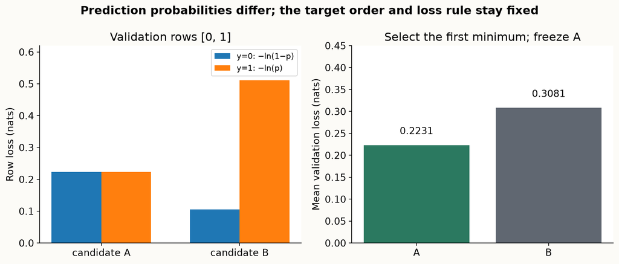

Synthetic validation trace: [0,1] targets; candidate A probabilities [.2,.8], B [.1,.6]. The same loss operator selects A at .2231 versus .3081 before test access. Full-size figure.

**Connecting the ideas.** A reproducible metric still needs an appropriate evidence unit. Preserve method pairing and aggregate within each dataset before across datasets; repeated seeds describe conditional variation, not a multiplied task population.

**A candidate is a recipe, with declared tie rules.** A candidate is a declared recipe, not just a final network. Here XGBoost tries depths 3 and 6 with learning rate .05 and 100 trees. Corrected TabM tries learning rates .001 and .003 for 24 epochs, k=8, width 64, depth 3 and dropout .1. At each epoch, compute ensemble validation loss and keep the **last** epoch at the minimum, matching the explicit stopping policy. Across the two candidate recipes, choose the **first** minimum. The two tie rules concern different axes and are recorded separately.

**What each artifact can and cannot prove.** The new artifact saves every candidate's selected validation probabilities, all epoch losses, selected epoch, fitted-weight digest and preprocessing statistics. A checker can recompute each selected validation loss and recover both choices. The old archive contains validation loss scalars and selected indices but no validation probabilities. Its argmin replay is useful, but by itself cannot verify that those losses were calculated from the declared validation rows. Separate original-package replay evidence is needed for that stronger claim.

> **Scope check.** Equal candidate counts would still not imply equal tuning cost. The archived pretrained arms used one estimator/recipe, while the fitted baselines chose between two recipes and TabM additionally chose an epoch. This is a deliberately small comparison of specified downstream procedures. It is not a search-budget-matched reproduction of TabArena's tuning and ensembling machinery.

## Choose the statistical unit before calculating uncertainty

> **In plain terms.** Decide *what* you are averaging over — datasets, seeds or rows — before computing any error bar. Repeats of one split are not new datasets.

**Pair before you subtract.** Start with the per-dataset seed points and loss gaps. For arm a versus XGBoost on dataset d and seed s, Δ[d,s]=loss[a,d,s]−loss[XGBoost,d,s]. Negative values favor a. Pair by dataset and declared downstream seed; never subtract unrelated rows. The main table reports seed means and **sample standard deviations**, which describe this limited source of variation. A t interval from three seeds would have only two degrees of freedom and still condition on this fixed split. It would not cover different datasets or pretraining histories.

**Rank at the dataset unit.** For the primary rank summary, average seeds inside each dataset, rank those means with smaller loss better, and average ranks across the five datasets. A tie gets the average occupied position. This protects each dataset's weight from the number of repetitions. It does not make the five convenience-selected public tables a random sample of deployment tasks.

**Worked example — why the aggregation rule matters.** Order matters. Suppose A has seed losses [0.1,0.1,1.0], while B has [0.2,0.2,0.2]. A wins two of three seed-wise contests, so its average seed rank is better. But A's mean loss is 0.4 and B's is 0.2; ranking the means favors B. The lesson uses the latter operator. The TabPFN-3 TALENT appendix ranks each dataset/split pair before averaging, a different experimental design. Never call the two statistics identical.

**The paired bootstrap.** The paired bootstrap first averages Δ within each dataset, then draws five dataset indices with replacement for each replicate and averages the selected differences. All model/seed pairs from a selected dataset move together. The 2.5th and 97.5th percentiles of 2,000 replicate means form an empirical interval. It describes resampling this five-dataset collection, with considerable small-sample limitations. It cannot justify a population-wide guarantee or turn 15 repeated runs into 15 independent datasets.

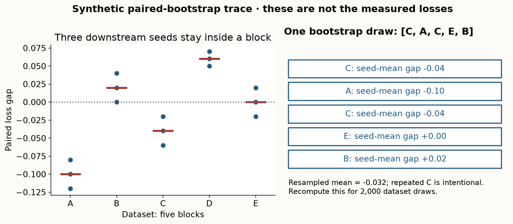

Synthetic paired-bootstrap trace. Average the three seed gaps inside each dataset, then resample dataset means; a repeated dataset carries its paired evidence together. Full-size figure.

> **Scope check.** The exploratory Friedman test asks whether dataset-level ranks differ beyond its null model. The Nemenyi critical difference is a multiple-comparison threshold **in rank units**, computed for the declared number of models and datasets. It is not a confidence interval around a log loss. With only five datasets, a visually ordered rank plot can easily fail to resolve pairwise differences. A non-significant test is not evidence of equivalence; an equivalence claim would require a meaningful tolerance and a design capable of testing it.

## Read the measured comparison before recommending a model

> **In plain terms.** Predict what can and cannot move when you add an opponent or fix a bug, then read the table against that prediction.

Before revealing the table, predict which quantity can change when a new opponent is added: an existing probability, an existing loss, or its rank. Then predict whether correcting an implementation must improve its test score. The latter prediction should make you uncomfortable: correct mathematics removes a fidelity error, not the randomness and task dependence of empirical performance.

### Author-reference evidence · separate from your live run

| Dataset | XGBoost | TabM-mini-v2 | TabPFN-v2 | TabICL-v1.1 | TabPFN-2.5-synthetic | TabPFN-3 | TabICLv2 |
| --- | --- | --- | --- | --- | --- | --- | --- |
| diabetes | 0.5336 ± 0.0044 | 0.5162 ± 0.0109 | 0.5256 ± 0.0028 | 0.5053 ± 0.0000 | 0.5469 ± 0.0092 | 0.5253 ± 0.0020 | 0.5192 ± 0.0000 |
| blood_transfusion | 0.4494 ± 0.0029 | 0.4356 ± 0.0008 | 0.4405 ± 0.0013 | 0.4540 ± 0.0000 | 0.4277 ± 0.0016 | 0.4351 ± 0.0018 | 0.4333 ± 0.0000 |
| kc1 | 0.3424 ± 0.0055 | 0.3134 ± 0.0007 | 0.3157 ± 0.0018 | 0.3375 ± 0.0000 | 0.3457 ± 0.0099 | 0.3466 ± 0.0080 | 0.3240 ± 0.0000 |
| phoneme | 0.2667 ± 0.0069 | 0.3623 ± 0.0111 | 0.2416 ± 0.0060 | 0.2700 ± 0.0000 | 0.2517 ± 0.0017 | 0.2382 ± 0.0035 | 0.2434 ± 0.0000 |
| breast_cancer | 0.1315 ± 0.0012 | 0.0758 ± 0.0117 | 0.1159 ± 0.0123 | 0.0849 ± 0.0000 | 0.1213 ± 0.0129 | 0.1376 ± 0.0028 | 0.1047 ± 0.0000 |

Test log loss, mean ± sample SD over three downstream seeds. Six archived arms plus fresh corrected TabM. Smaller is better; fixed split and restricted procedures.

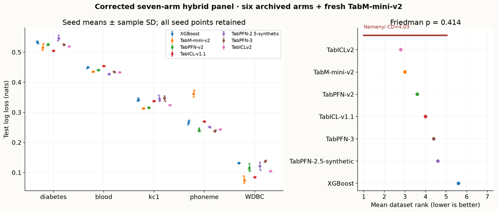

Actual corrected seven-arm hybrid panel: six archived arms plus freshly fitted corrected TabM. Dots retain three downstream seeds; bars are sample SD. Five dataset blocks support exploratory Friedman/Nemenyi summaries, not broad winner claims. Full-size figure.

**Measured outcome.** TabICLv2 has the smallest mean dataset rank (2.80) in the corrected seven-arm pool. The exploratory Friedman p-value is 0.414; the Nemenyi critical difference is 4.03 rank units. These summaries do not resolve a general winner from five fixed small tables.

The fresh XGBoost replay control differs from its archived test probabilities by at most 0. This verifies that control under the recorded local recipes; its wall-clock cost is a new observation. The 30 fresh selected fits retain 60 candidate validation probability vectors and 720 neural epoch losses.

The feature-erasure prediction is supported at the dataset-average level: XGBoost-fresh-control: mean loss increase +0.0622 nats, 0 of 15 seed cases improve, TabM-mini-v2: mean loss increase +0.0322 nats, 2 of 15 seed cases improve. Every negative case stays in the evidence. A mean degradation does not imply all rows or datasets degrade.

The corrected-minus-legacy TabM mean-loss differences are diabetes +0.0058, blood_transfusion -0.0015, kc1 -0.0052, phoneme -0.0260, breast_cancer +0.0057. Correcting paper fidelity is not a promise to improve every held-out score.

> **Scope check.** The corrected main panel deliberately combines fresh TabM fits with archived, independently scoreable probabilities from the other six procedures. That supports a **hybrid local comparison** on the frozen rows. It is neither seven fresh training runs nor a comparison under one contemporaneous software environment. The original seven-arm and eight-arm diagnostic summaries remain available in the result JSON. A version repair should preserve its counter-evidence as carefully as its favorable outcomes.

## Measure lifecycle cost, then stress one information source

> **In plain terms.** Total cost depends on how many times you predict, not just how fast you fit. Then erase the feature with the largest training-set absolute linear correlation to see how much the fitted model leaned on it. This rule need not identify the most predictive feature.

**A simple workload model.** Let F be preparation plus candidate-selection seconds and P the seconds for the declared prediction batch. For B repeated batches on an unchanged context, a simple workload model is C(B)=F+BP. A procedure costing F=100, P=1 ties one costing F=10, P=4 at B=30. For fewer batches the lower preparation cost wins; for more batches the lower per-batch cost wins. This is a workload calculation, not a measurement of caching behavior the runner did not execute.

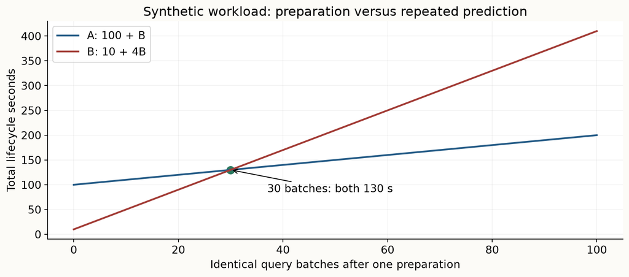

Synthetic lifecycle arithmetic: A=100+B seconds and B=10+4B seconds meet at 30 identical query batches. This is a workload illustration, not a measured serving or cache benchmark. Full-size figure.

**Keep the timing boundaries explicit.** Keep download, checkpoint loading, common data preparation, model-specific preparation, candidate validation and selected test prediction boundaries explicit. The local timers include candidate fitting and validation, then one selected prediction call. Common loading/imputation is excluded. Archived pretrained `fit` may defer work into `predict`; its preparation timer therefore need not be directly comparable to a cache-building deployment fit. The times were collected on a shared CPU host and cannot establish controlled hardware efficiency.

> **Scope check.** The source reports use larger protocols. TabPFN-3's TabArena evaluation includes eight-fold bagging for fit-time cross-validation and a full-training refit; its 816 tasks span 51 datasets. Binary TabArena scores use AUROC, multiclass uses log loss and regression uses RMSE. Its TALENT comparisons use accuracy for classification and RMSE for regression, with 26 development datasets excluded from the main slice. Our five binary log-loss tasks use neither complete protocol. Elo, rank and relative error summaries from those sources should not be spliced into this local loss table. See [Appendices E.2–E.3](https://arxiv.org/html/2605.13986v1#A5).

**The feature-erasure stress test.** Now test a specific information dependency. For each dataset, compute the **largest absolute Pearson correlation with the target using training rows only**. Pearson correlation measures centered linear association normalized by the feature and target scales. Exact ties choose the first feature. Replace that feature in every test query with its training median. Freeze the selected model, all other query values, row IDs and targets. Run the same intervention for fresh XGBoost and corrected TabM. The prespecified prediction is that dataset-average log loss increases for both; a failed prediction belongs in the report.

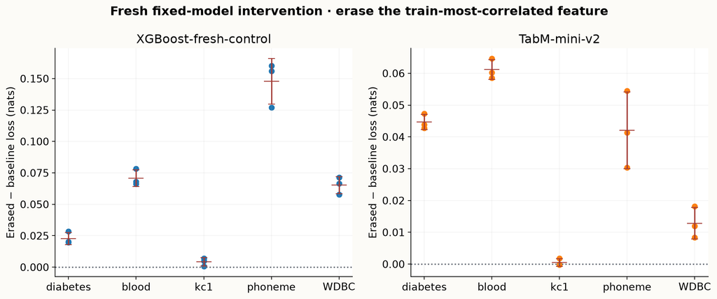

Actual fresh fits on identical rows. Query feature with highest absolute training-target correlation is replaced by its training median; selected predictors are frozen. Positive loss gaps indicate damage. Dots are seeds; bars are sample SD. Full-size figure.

**Connecting the ideas.** Quality, lifecycle cost and information stress now bound what the single-table system establishes. The relational handoff should identify a specific missing entity or event relationship and test its value against this strong baseline under the same availability rules.

**What the stress test does not prove.** This is an information-loss stress test, not a causal feature-importance estimate or an estimate of every missing-data mechanism. A high univariate correlation can be redundant with another feature; a noisy association can harm a small fitted model, so erasing it can improve held-out loss. Median replacement does not mean the deployed model learned how to use a newly missing sensor. Selecting the erased feature by the largest observed test degradation would answer a more adaptive question and would need separate validation. Retraining after deletion would answer another question again: whether the remaining features can compensate after adaptation.

## Turn the evidence into a relational research handoff

> **In plain terms.** End by turning this discipline into a concrete, falsifiable relational experiment — one where structure either earns its cost or does not.

**Fix the entity and the horizon.** Specify an entity, prediction time t, horizon h and target. For a future customer task, legal information might include interactions and linked account events occurring and available before t, with any labels used as inputs also available before t. A strong aggregate baseline can use counts, recency, sums and prior outcomes constructed from that legal history. A relational model may preserve typed links, sequence structure or interactions discarded by those aggregates. Compare this concrete information representation while holding target rows, horizon and selection policy fixed.

**Read the report's relational section for what it separates.** The [TabPFN-3 relational section](https://arxiv.org/html/2605.13986v1#S3.SS4) is useful precisely because it distinguishes claims. It reports TabPFN-REL as strongest among the compared relational foundation models, while RelGNN remains stronger overall on its aggregate metrics. It also flags results under potentially different data regimes. An RFM ranking is not a claim that every relational foundation model beats supervised relational learning. The section's RDBLearn comparisons also identify early checkpoint variants; our binary `v3_default` archive does not reproduce those results.

**Worked handoff — equal counts, different order.** At cutoff 10, customer A has `purchase@2 → complaint@8`; customer B has `complaint@2 → purchase@8`. Both events were available by time 10. A table containing only one purchase and one complaint maps both customers to the same vector `[1,1]`. An order-aware representation distinguishes them. But a stronger table containing last-event type or per-type recency also distinguishes them: A has recencies `[8,2]`, B `[2,8]`. So beating counts alone would not establish that a relational architecture is necessary. Prespecify the stronger aggregate baseline, then compare on the same future-window targets. These two rows illustrate a representation collision; they are not evidence of a real predictive effect.

**Try the intervention.** Swap the event types between times 2 and 8 while keeping each customer's timestamps, membership and type counts fixed. Counts stay `[1,1]`; per-type recencies and order both change. If the hypothesis is about order beyond recency, this intervention does not isolate it: add a recency-matched design or narrow the claim to temporal arrangement. The question determines which properties the control must preserve.

**A defensible, falsifiable handoff.** A defensible handoff might predict: preserving the order of recent linked interactions improves a future-window metric over a legal aggregate table when the label depends on event order. The discriminating intervention shuffles order while preserving entity membership and counts, with tuning frozen before the test window. If the aggregate table plus a deployable pretrained learner matches the relational model within a prespecified practical margin at lower measured cost, that is evidence against needing the extra structure in this regime. Preserve it rather than replacing the task after seeing the answer.

## EXIT: defend what your artifact actually establishes

> **In plain terms.** Your deliverable is a defended argument, not a green checkmark. Keep separate what you implemented, fitted, audited and left unrun.

The notebook provides the corrected TabM architecture and full bounded training loop visibly. You implement six live operations: probability loss, validation choice, complete-panel aggregation, dataset bootstrap, lifecycle cost and feature erasure. These definitions are called by the actual experiment. CHECK cells test error cases and invariants, not only happy-path values. Your final JSON binds the data/archive identities, candidate traces, predictions, intervention, current code dependency graph and written interpretation.

Submit a recommendation for one declared use case, one counterexample to a broad winner claim and one falsifiable relational follow-up. Separate what you implemented, what you freshly fitted, which checkpoint predictions you audited, what independent replay verified and what remains unrun. The post-EXIT route increases the local fitting budget using the same visible code; a larger local preset does not become a reproduction of full pretraining or the original benchmark. The reproduction contract gives the executable routes and the protocol work still needed.

> **Scope check.** Ask the tutor to challenge your weakest link: row identity, validation independence, model fidelity, uncertainty, cost or transfer. Completion is a submitted and defended argument. Merely running the cells does not establish personal mastery.

## PROVIDED · Imports and immutable inputs

The original model outputs are input data for the audit. Actual fitting below uses the definitions in this notebook. A fresh timestamped output directory avoids overwriting previous experiments. No resume is promised.

```python
# PROVIDED — imports and independent output
import copy,hashlib,importlib.metadata,inspect,itertools,json,math,os,time,types,sys
from pathlib import Path
import numpy as np
import pandas as pd
import torch
from torch import nn
from scipy.stats import rankdata,friedmanchisquare,studentized_range,t
from sklearn.datasets import load_breast_cancer
from sklearn.model_selection import train_test_split
from sklearn.preprocessing import StandardScaler
from sklearn.impute import SimpleImputer
from xgboost import XGBClassifier
from IPython.display import display
# Pinned import dependency of the official comparator, not the teaching model.
import importlib.util,subprocess
if importlib.util.find_spec("rtdl_num_embeddings") is None:
    subprocess.check_call([sys.executable,"-m","pip","install","rtdl_num_embeddings==0.0.12"])
for directory in [Path.cwd(),Path.cwd()/'labs',Path.cwd().parent]:
    if (directory/'relkit').is_dir():ROOT=directory.resolve();sys.path.insert(0,str(ROOT));break
else:raise RuntimeError('Run bootstrap or start in labs')
from _prepare_l070_v2 import prepare_inputs
input_preparation=prepare_inputs(ROOT)
print("Exact public data snapshots",input_preparation["status"])
from relkit.data import load_tier_a,CACHE,SPECS
torch.set_num_threads(1)
output=Path(os.environ.get('L070_OUTPUT',str(ROOT/'data/cache/l070-student'/str(time.time_ns()))))
output.mkdir(parents=True,exist_ok=False)
```

```python
# PROVIDED — declared design and prediction before intervention
DATASETS=['diabetes/random', 'blood_transfusion/random', 'kc1/random', 'phoneme/random', 'breast_cancer/random']
ARCHIVE_ARMS=['XGBoost', 'TabM-mini', 'TabPFN-v2', 'TabICL-v1.1', 'TabPFN-2.5-synthetic', 'TabPFN-3', 'TabICLv2']
ARMS=['XGBoost', 'TabM-mini-v2', 'TabPFN-v2', 'TabICL-v1.1', 'TabPFN-2.5-synthetic', 'TabPFN-3', 'TabICLv2']
PRESETS70={'smoke': {'datasets': ['diabetes/random'], 'seeds': [0], 'epochs': 4, 'trees': 30}, 'lab': {'datasets': ['diabetes/random', 'blood_transfusion/random', 'kc1/random', 'phoneme/random', 'breast_cancer/random'], 'seeds': [0, 1, 2], 'epochs': 24, 'trees': 100}, 'closer': {'datasets': ['diabetes/random', 'blood_transfusion/random', 'kc1/random', 'phoneme/random', 'breast_cancer/random'], 'seeds': [0, 1, 2], 'epochs': 128, 'trees': 800}}
PROTOCOL70={'cap': 600, 'split_seeds': [70, 71], 'candidate_lrs': [0.001, 0.003], 'candidate_depths': [3, 6], 'width': 64, 'depth': 3, 'k': 8, 'dropout': 0.1, 'batch_size': 128, 'weight_decay': 0.0001, 'intervention': 'largest absolute train-only Pearson correlation, replace test feature with train median; frozen predictor', 'prediction': 'Feature erasure increases dataset-average log loss for both freshly fitted arms; signed prediction may fail', 'epoch_tie': 'last minimum', 'candidate_tie': 'first minimum', 'positive_class': 1}
print(PROTOCOL70["prediction"])
```

## TODO 1 · Reconstruct probability loss

**Goal:** Return binary log loss with float64 endpoint clipping and reject invalid inputs.

**Why:** A reversed class column or omitted row can hide behind a plausible saved score.

**Hint:** Check shape, range and class support before reducing row losses; probabilities mean P(y=1).

```python
# TODO — binary_loss
def binary_loss(y,p):
    raise NotImplementedError("Implement the live operation")
```

```python
# CHECK — binary_loss
assert abs(binary_loss([0,1],[.2,.8])+np.log(.8))<1e-12
assert np.isfinite(binary_loss([1],[0]))
try:binary_loss([0,1],[.1,np.nan]);raise AssertionError('Must reject nonfinite probabilities')
except ValueError:pass
print("CHECK passed: binary_loss")
```

## TODO 2 · Freeze a validation choice

**Goal:** Return the first minimum index of a finite nonempty validation vector.

**Why:** The real training loop uses this choice before any test prediction.

**Hint:** A tie is a protocol decision; NaN is not a losing candidate to silently ignore.

```python
# TODO — choose_candidate
def choose_candidate(errors):
    raise NotImplementedError("Implement the live operation")
```

```python
# CHECK — choose_candidate
assert choose_candidate([.3,.2,.2])==1
try:choose_candidate([]);raise AssertionError('Must reject empty candidate set')
except ValueError:pass
print("CHECK passed: choose_candidate")
```

## TODO 3 · Require the complete declared panel

**Goal:** Validate the Cartesian design, then return seed means, sample SD, ranks and exploratory rank statistics.

**Why:** Inferring the roster from observed rows can hide an entirely missing arm.

**Hint:** Compare explicit expected keys; average seeds inside each dataset before assigning average-tie ranks.

Return keys: `datasets,arms,seeds,values,means,sample_sd,dataset_ranks,mean_ranks,friedman_p,nemenyi_cd,unit`. Values has shape datasets×arms×seeds in the supplied order. Use `None` for sample SD with one seed, Friedman p when fewer than three datasets/models or every row is tied, and critical difference with one model. Use average ties, scipy Friedman on dataset mean columns, and CD=`studentized_range.ppf(.95,k,inf)*sqrt(k*(k+1)/(12*n))`. The exercise is correctly selecting and aggregating the units, not reimplementing a distribution quantile.

```python
# TODO — complete_panel
def complete_panel(records,datasets,arms,seeds):
    raise NotImplementedError("Implement the live operation")
```

```python
# CHECK — complete_panel
rr=[dict(dataset=d,arm=a,seed=k,error=float(k)) for d in ['A','B','C'] for a in ['x','m','z'] for k in [0,1,2]]
z=complete_panel(rr,['A','B','C'],['x','m','z'],[0,1,2]);assert z['mean_ranks']==dict(x=2.,m=2.,z=2.)
try:complete_panel(rr[:-1],['A','B','C'],['x','m','z'],[0,1,2]);raise AssertionError('Missing crossed cell accepted')
except ValueError:pass
print("CHECK passed: complete_panel")
```

## TODO 4 · Resample the paired dataset unit

**Goal:** Return mean, percentile95, units, dataset_means, repetitions, seed and scope from a dataset-by-seed gap matrix.

**Why:** Fifteen downstream repetitions are not fifteen independent datasets.

**Hint:** Average within each row of the matrix, then resample those dataset means with one local RNG.

```python
# TODO — dataset_bootstrap
def dataset_bootstrap(differences,repetitions=2000,seed=70):
    raise NotImplementedError("Implement the live operation")
```

```python
# CHECK — dataset_bootstrap
z=dataset_bootstrap(np.array([[-.1,-.2,-.3],[.2,.3,.4]]),2000,70)
assert z['units']==2 and abs(z['mean']-.05)<1e-12
assert z==dataset_bootstrap(np.array([[-.1,-.2,-.3],[.2,.3,.4]]),2000,70)
print("CHECK passed: dataset_bootstrap")
```

## TODO 5 · Price a repeated workload

**Goal:** Return total seconds for one preparation and a declared count of identical query batches.

**Why:** A fast fit can be overwhelmed by repeated context-conditioned inference.

**Hint:** Validate finite nonnegative inputs; the workload is a simple linear model, not a measured cache speedup.

```python
# TODO — lifecycle_cost
def lifecycle_cost(prepare_seconds,predict_seconds,batches):
    raise NotImplementedError("Implement the live operation")
```

```python
# CHECK — lifecycle_cost
assert lifecycle_cost(100,1,30)==lifecycle_cost(10,4,30)==130
try:lifecycle_cost(-1,2,3);raise AssertionError('Negative preparation cost accepted')
except ValueError:pass
print("CHECK passed: lifecycle_cost")
```

## TODO 6 · Run a frozen feature-loss intervention

**Goal:** Return a new floating-point query array with one column replaced by its training median.

**Why:** The live experiment removes train-selected information without refitting or consulting test degradation.

**Hint:** Retain every other coordinate and the input arrays; integer inputs must not truncate a fractional median.

```python
# TODO — erase_feature
def erase_feature(train,query,column):
    raise NotImplementedError("Implement the live operation")
```

```python
# CHECK — erase_feature
q=np.array([[0,8],[9,10]]);before=q.copy();z=erase_feature(np.array([[2,0],[3,1]]),q,0)
np.testing.assert_array_equal(z,[[2.5,8],[2.5,10]]);np.testing.assert_array_equal(q,before)
print("CHECK passed: erase_feature")
```

## PROVIDED · Correct initialization and ensemble operators

Row-vector weights have shape [input,output], so fan-in is the penultimate axis. Mini keeps only the first R; probabilities are averaged after per-member softmax.

```python
# PROVIDED — corrected model

def kaiming_(t):
    """Linear-style U(-1/sqrt(d_in), +1/sqrt(d_in)) for [...,d_in,d_out].

    PyTorch's kaiming helper assumes [d_out,d_in] and is wrong for this layout.
    Explicit fan-in also handles the independent [k,d_in,d_out] heads.
    """
    bound = 1 / math.sqrt(t.shape[-2])
    return nn.init.uniform_(t, -bound, bound)

def sign_pm1(k, d, generator=None):
    """Random ±1 initialisation for the first adapter (paper §3.2: diversity)."""
    return torch.where(torch.rand(k, d, generator=generator) < .5, -1., 1.)

def batchensemble_linear(x, weight, R, S, bias):
    """BatchEnsemble layer over k members (paper §3.2).

    x: [B, k, d_in]; weight (shared W): [d_in, d_out]; R: [k, d_in] or None;
    S: [k, d_out] or None; bias (B): [k, d_out]. Returns [B, k, d_out] computed as
    ((x ⊙ R) W) ⊙ S + B, with R/S skipped when None (the mini variant).
    """
    if R is not None:
        x = x * R
    h = torch.einsum('bki,io->bko', x, weight)
    if S is not None:
        h = h * S
    return h + bias

def packed_head(h, weight, bias):
    """k independent output heads. h: [B,k,d]; weight: [k,d,d_y]; bias: [k,d_y]."""
    return torch.einsum('bkd,kdo->bko', h, weight) + bias

def member_mean_loss(out, y, regression):
    """Mean over the k members of each member's loss (paper §5.1). out: [B,k,d_y]."""
    k = out.shape[1]
    if regression:
        return ((out[:, :, 0] - y.unsqueeze(1)) ** 2).mean()
    logp = out.log_softmax(-1)
    nll = -logp.gather(-1, y.view(-1, 1, 1).expand(-1, k, 1)).squeeze(-1)
    return nll.mean()

def ensemble_predict(out, regression):
    """Mean prediction over members: raw for regression, probabilities otherwise."""
    if regression:
        return out.mean(1)[:, 0]
    return out.softmax(-1).mean(1)
```

## PROVIDED · The full corrected numeric TabM

These are the actual classes constructed by your experiment: shared mini backbone biases, no S adapters, eight independent heads. No model code is hidden behind an import.

```python
# PROVIDED — corrected model

class BatchEnsembleLinear(nn.Module):
    """One shared W with per-member multiplicative (R,S) and additive (B) adapters.

    ``first`` selects the diversity-creating adapter that is initialised with
    random ±1; all other adapters are initialised so they have no effect at the
    start (later R=S=1, identical random bias rows), matching the ``TabM`` initialisation in paper §3.3.
    ``shared_rs`` (mini) keeps only the first R, with ordinary shared biases.
    There is no S even in the first mini layer; all later R/S are absent.
    """
    def __init__(self, din, dout, k, first=False, shared_rs=False, generator=None):
        super().__init__()
        self.k = k
        self.weight = nn.Parameter(kaiming_(torch.empty(din, dout)))
        # Full TabM starts each member bias with the same nn.Linear-style draw.
        base_bias = torch.empty(dout).uniform_(-1 / math.sqrt(din), 1 / math.sqrt(din))
        self.bias = nn.Parameter(base_bias if shared_rs else base_bias.repeat(k, 1))
        self.R = nn.Parameter(sign_pm1(k, din, generator) if first else torch.ones(k, din)) \
            if first or not shared_rs else None
        self.S = None if shared_rs else nn.Parameter(torch.ones(k, dout))

    def forward(self, x):                                          # x: [B, k, din]
        return batchensemble_linear(x, self.weight, self.R, self.S, self.bias)

class PackedHead(nn.Module):
    """k independent output heads (one per submodel); d_y is tiny so this is cheap."""
    def __init__(self, width, dy, k):
        super().__init__()
        self.weight = nn.Parameter(kaiming_(torch.empty(k, width, dy)))
        self.bias = nn.Parameter(torch.empty(k, dy).uniform_(-1 / math.sqrt(width), 1 / math.sqrt(width)))

    def forward(self, h):                                          # h: [B, k, width]
        return packed_head(h, self.weight, self.bias)

class TabM(nn.Module):
    """One model imitating an ensemble of k MLPs (paper §3.3).

    forward returns per-member outputs of shape [B, k, d_y]. Use
    :meth:`predict` for the mean (ensemble) prediction and :meth:`member_losses`
    for the mean-over-members training objective.
    """
    def __init__(self, din, k=32, width=64, depth=3, dropout=.1,
                 regression=False, arch='mini', seed=0):
        super().__init__()
        assert arch in ('mini', 'tabm')
        g = torch.Generator().manual_seed(seed)
        self.k, self.regression, self.arch = k, regression, arch
        dims = [din] + [width] * depth
        shared_rs = arch == 'mini'
        self.blocks = nn.ModuleList(
            BatchEnsembleLinear(a, b, k, first=(i == 0), shared_rs=shared_rs, generator=g)
            for i, (a, b) in enumerate(zip(dims[:-1], dims[1:])))
        self.dropout = nn.Dropout(dropout)
        self.head = PackedHead(width, 1 if regression else 2, k)

    def forward(self, x):
        # 3-D inputs permit independent per-member batches in the closer track.
        h = x.unsqueeze(1).expand(-1, self.k, -1) if x.ndim == 2 else x
        if h.ndim != 3 or h.shape[1] != self.k:
            raise ValueError('Expected [B,din] or [B,k,din]')
        for block in self.blocks:
            h = self.dropout(torch.relu(block(h)))
        return self.head(h)                                       # [B,k,d_y]

    def predict(self, x):
        """Ensemble prediction: mean over members (probabilities if classifying)."""
        return ensemble_predict(self(x), self.regression)

    def member_losses(self, x, y):
        """Mean over the k members of each member's supervised loss (paper §5.1)."""
        return member_mean_loss(self(x), y, self.regression)

    def member_predictions(self, x):
        """Per-member predictions [B,k,(d_y)] for individual-vs-collective analysis."""
        out = self(x)
        if self.regression:
            return out[:, :, 0]
        return out.softmax(-1)
```

## PROVIDED · Data and archive alignment

Load original rows, reproduce fixed partitions and class semantics, fit training imputation, then reconstruct every saved test loss. The old validation scalar trace cannot by itself reconstruct validation probabilities.

```python
# PROVIDED — Data and archive alignment

def load_task(name,root):
    """Exact original 600-row cap and 70/71 splits, with raw semantic class map."""
    name=name.split('/')[0]
    if name=='breast_cancer':
        b=load_breast_cancer(as_frame=True);x,y=b.data,b.target;class_map={str(i):str(v) for i,v in enumerate(b.target_names)}
        digest=hashlib.sha256(pd.util.hash_pandas_object(x,index=True).values.tobytes()+y.to_numpy().tobytes()).hexdigest()
    else:
        x,y=load_tier_a(name);cache=Path(root)/'data/cache'/(name+'.parquet');digest=hashlib.sha256(cache.read_bytes()).hexdigest()
        f=pd.read_parquet(cache);raw=f[SPECS[name]['target']]
        class_map={str(i):v for i,v in enumerate(sorted(raw.astype(str).unique()))} if str(raw.dtype) in ['object','category'] else {str(int(v)):str(v) for v in sorted(raw.unique())}
    y=np.asarray(y,dtype='int64');ids=np.arange(len(y))
    if len(ids)>600:ids=np.sort(np.random.default_rng(70).choice(ids,600,replace=False))
    tr,te=train_test_split(ids,test_size=.2,random_state=70,stratify=y[ids]);tr,va=train_test_split(tr,test_size=.25,random_state=71,stratify=y[tr]);parts=dict(train=tr,val=va,test=te)
    if len(np.unique(np.concatenate(list(parts.values()))))!=sum(map(len,parts.values())):raise ValueError('Overlapping partitions')
    prep=SimpleImputer(strategy='median',keep_empty_features=True).fit(x.iloc[tr])
    xx={k:prep.transform(x.iloc[v]).astype('float32') for k,v in parts.items()};yy={k:y[v] for k,v in parts.items()}
    audit=dict(ids={k:v.tolist() for k,v in parts.items()},data_sha256=digest,class_map=class_map,
        feature_names=x.columns.tolist(),imputation_median=prep.statistics_.tolist(),positive_class=1)
    return xx,yy,audit

def audit_archive(root,namespace=None):
    s=globals() if namespace is None else namespace;root=Path(root);archive=json.loads((root/'_verify_l070_results.json').read_text());maximum=0.;datasets={}
    for name in DATASETS:
        x,y,audit=s['load_task'](name,root);old=archive['datasets'][name]
        if audit['ids']!=old['ids'] or audit['data_sha256']!=old['data_sha256']:raise ValueError('Historical raw data or row identity changed')
        datasets[name]=audit
        for r in [z for z in archive['records'] if z['dataset']==name]:
            if r['targets']!=y['test'].tolist():raise ValueError('Archive targets disagree with raw data positive class')
            delta=abs(s['binary_loss'](r['targets'],r['predictions'])-r['error']);maximum=max(maximum,delta)
            if delta>2e-7:raise ValueError('Saved prediction score mismatch')
            if r['selected']!=s['choose_candidate'](r['validation_errors']):raise ValueError('Historical selection differs from validation minimum')
    summary=s['complete_panel'](archive['records'],DATASETS,ARCHIVE_ARMS,[0,1,2])
    return dict(status='PASS',records=len(archive['records']),maximum_loss_delta=maximum,datasets=datasets,
        archive_sha256=hashlib.sha256((root/'_verify_l070_results.json').read_bytes()).hexdigest(),summary=summary,
        validation_probability_reconstruction='NOT_CHECKED: original JSON saves only validation scalar errors',
        pretrained_refit='NOT_RUN by this audit; separate independent source replay may establish prediction parity',
        checkpoints=json.loads((root/'_sources_foundation.json').read_text()),historical_versions=archive['versions'],current_versions=archive['current_versions'])
```

## PROVIDED · Bind actual runtime definitions and weights

The graph traverses nested code objects, function defaults, closures, global helpers and actual model methods. Selected weights and runtime settings are separate identities; external libraries have recorded versions.

```python
# PROVIDED — Bind actual runtime definitions and weights

def stable_code(obj,seen=None):
    """Stable semantic dependency graph including nested code, defaults and closures."""
    seen=set() if seen is None else seen
    if isinstance(obj,types.CodeType):return [obj.co_code.hex(),obj.co_names,obj.co_varnames,obj.co_freevars,obj.co_cellvars,obj.co_argcount,obj.co_posonlyargcount,obj.co_kwonlyargcount,obj.co_flags,[stable_code(v,seen) for v in obj.co_consts]]
    if inspect.isclass(obj):
        if id(obj) in seen:return ['recursive-class',obj.__name__]
        seen.add(id(obj));return {k:stable_code(v,seen) for k,v in sorted(vars(obj).items()) if isinstance(v,types.FunctionType)}
    if isinstance(obj,types.FunctionType):
        if id(obj) in seen:return ['recursive',obj.__name__]
        seen.add(id(obj));names=set()
        def visit(code):
            names.update(code.co_names)
            for v in code.co_consts:
                if isinstance(v,types.CodeType):visit(v)
        visit(obj.__code__);dependencies={}
        for n in sorted(names):
            if n not in obj.__globals__:continue
            v=obj.__globals__[n]
            if isinstance(v,(types.FunctionType,type)) and (getattr(v,'__module__',None)==obj.__module__ or str(getattr(v,'__module__','')).startswith('relkit.')):dependencies[n]=stable_code(v,seen)
            elif n.isupper() and isinstance(v,(dict,list,tuple,str,int,float)):dependencies[n]=stable_code(v,seen)
        return [obj.__name__,stable_code(obj.__code__,seen),stable_code(obj.__defaults__,seen),stable_code(obj.__kwdefaults__,seen),stable_code([v.cell_contents for v in obj.__closure__ or []],seen),dependencies]
    if isinstance(obj,dict):return {str(k):stable_code(v,seen) for k,v in sorted(obj.items(),key=lambda p:str(p[0]))}
    if isinstance(obj,(tuple,list)):return [stable_code(v,seen) for v in obj]
    if isinstance(obj,np.ndarray):return [str(obj.dtype),obj.shape,hashlib.sha256(obj.tobytes()).hexdigest()]
    if isinstance(obj,Path):return ['Path',str(obj)]
    if isinstance(obj,float) and not math.isfinite(obj):return ['nonfinite',str(obj)]
    if obj is None or isinstance(obj,(bool,int,float,str)):return obj
    return [type(obj).__module__,type(obj).__name__]

def model_identity(model):
    if isinstance(model,XGBClassifier):return dict(weights=hashlib.sha256(model.get_booster().save_raw()).hexdigest(),runtime=stable_code(model.get_params()))
    h=hashlib.sha256();runtime={}
    for name,tensor in model.state_dict().items():h.update(name.encode());h.update(str((tensor.shape,tensor.dtype)).encode());h.update(tensor.detach().numpy().tobytes())
    for name,module in model.named_modules():
        if 'forward' in vars(module) or module._forward_hooks or module._forward_pre_hooks:raise RuntimeError('Untracked model hook or instance method')
        runtime[name]=dict(type=type(module).__qualname__,forward=stable_code(module.forward.__func__),settings=stable_code({k:v for k,v in vars(module).items() if not k.startswith('_')}))
    return dict(weights=h.hexdigest(),runtime_sha256=hashlib.sha256(json.dumps(runtime,sort_keys=True).encode()).hexdigest())

def kernel_identity(namespace,root):
    names=['binary_loss','choose_candidate','complete_panel','dataset_bootstrap','lifecycle_cost','erase_feature','load_task','fit_candidate','run_experiment','audit_archive','model_identity','TabM','BatchEnsembleLinear','PackedHead']
    payload=dict(xgboost_methods={n:stable_code(getattr(namespace['XGBClassifier'],n)) for n in ['__init__','fit','predict_proba']},functions={n:stable_code(namespace[n]) for n in names},protocol=PROTOCOL70,
        versions={p:importlib.metadata.version(p) for p in ['numpy','pandas','torch','scipy','scikit-learn','xgboost']},
        data_loader_sha256=hashlib.sha256((Path(root)/'relkit/data.py').read_bytes()).hexdigest(),
        model_file_sha256=hashlib.sha256((Path(root)/'relkit/tabm_v2.py').read_bytes()).hexdigest(),
        archive_sha256=hashlib.sha256((Path(root)/'_verify_l070_results.json').read_bytes()).hexdigest())
    return dict(sha256=hashlib.sha256(json.dumps(payload,sort_keys=True).encode()).hexdigest(),payload=payload)
```

## PROVIDED · Candidate fitting before test access

Read this loop line by line. Every candidate sees only train and validation; all epoch losses and final validation probabilities are retained. The live student binary_loss controls epoch selection.

```python
# PROVIDED — Candidate fitting before test access

def fit_candidate(arm,train,ytrain,val,yval,seed,candidate,cfg,namespace):
    """No test parameter. Persist every epoch loss and selected validation probabilities."""
    s=namespace;begin=time.perf_counter()
    if arm=='XGBoost-fresh-control':
        model=s['XGBClassifier'](n_estimators=cfg['trees'],max_depth=[3,6][candidate],learning_rate=.05,n_jobs=1,
            random_state=seed,subsample=.8,colsample_bytree=.8,tree_method='hist');model.fit(train,ytrain)
        def predict(z):return model.predict_proba(z)[:,list(model.classes_).index(1)].astype(float)
        vp=predict(val);history=[s['binary_loss'](yval,vp)];epoch=None;preprocessing=None
    else:
        torch.manual_seed(seed);prep=StandardScaler().fit(train);tr=torch.tensor(prep.transform(train),dtype=torch.float32);va=torch.tensor(prep.transform(val),dtype=torch.float32);yt=torch.tensor(ytrain,dtype=torch.long)
        model=s['TabM'](din=tr.shape[1],width=64,depth=3,k=8,arch='mini',seed=seed,dropout=.1)
        opt=torch.optim.AdamW(model.parameters(),lr=[.001,.003][candidate],weight_decay=1e-4)
        best=float('inf');history=[];state=None;epoch=None
        for step in range(cfg['epochs']):
            model.train()
            for idx in torch.randperm(len(tr)).split(128):
                loss=model.member_losses(tr[idx],yt[idx]);opt.zero_grad();loss.backward();opt.step()
            model.eval()
            with torch.no_grad():p=model.predict(va)[:,1].numpy()
            error=s['binary_loss'](yval,p);history.append(error)
            if error<=best:best=error;state=copy.deepcopy(model.state_dict());epoch=step+1
        model.load_state_dict(state);model.eval()
        def predict(z):
            with torch.no_grad():return model.predict(torch.tensor(prep.transform(z),dtype=torch.float32))[:,1].numpy().astype(float)
        vp=predict(val);preprocessing=dict(mean=prep.mean_.tolist(),scale=prep.scale_.tolist())
    trace=dict(candidate=candidate,validation_predictions=vp.tolist(),validation_error=s['binary_loss'](yval,vp),epoch_losses=history,
        selected_epoch=epoch,seconds=time.perf_counter()-begin,model_identity=s['model_identity'](model),preprocessing=preprocessing)
    return predict,trace
```

## PROVIDED · Paired fitting, intervention and complete summary

The dynamic namespace calls your six functions. The erased feature is selected by training-only correlation, never by test degradation. The primary panel replaces the old TabM variant and keeps all six other archived arms.

```python
# PROVIDED — Paired fitting, intervention and complete summary

def run_experiment(root,config=None,namespace=None,output=None):
    """Fresh bounded fits and frozen test intervention; no resume or implicit downloads."""
    root=Path(root);s=globals() if namespace is None else namespace;cfg=copy.deepcopy(PRESETS70['lab'] if config is None else config)
    if output and Path(output).exists():raise FileExistsError('Choose a fresh output; historical evidence must remain immutable')
    torch.set_num_threads(1);identity=s['kernel_identity'](s,root);start=time.perf_counter();archive=s['audit_archive'](root,s)
    result=dict(schema='l070-v2',config=cfg,protocol=PROTOCOL70,kernel_identity=identity,archive_audit=archive,datasets={},records=[],status='IN_PROGRESS',paper_reproduction='INCOMPARABLE: local fixed five-table panel, not original paper protocols')
    for name in cfg['datasets']:
        x,y,audit=s['load_task'](name,root);result['datasets'][name]=audit
        # A prespecified target-informed TRAIN statistic, never chosen from test degradation.
        centered=x['train']-x['train'].mean(0);target=y['train']-y['train'].mean();denom=np.sqrt((centered**2).sum(0)*(target**2).sum());correlation=np.divide(centered.T@target,denom,out=np.zeros(centered.shape[1]),where=denom>0);column=int(np.argmax(abs(correlation)))
        changed=s['erase_feature'](x['train'],x['test'],column)
        for seed in cfg['seeds']:
            for arm in ['XGBoost-fresh-control','TabM-mini-v2']:
                candidates=[s['fit_candidate'](arm,x['train'],y['train'],x['val'],y['val'],seed,i,cfg,s) for i in range(2)]
                selected=s['choose_candidate']([c[1]['validation_error'] for c in candidates]);predict,trace=candidates[selected]
                # First model test prediction after validation selection. Labels only enter scoring.
                tick=time.perf_counter();p=predict(x['test']);predict_seconds=time.perf_counter()-tick;damaged=predict(changed)
                fit_seconds=sum(c[1]['seconds'] for c in candidates)
                row=dict(dataset=name,arm=arm,seed=seed,error=s['binary_loss'](y['test'],p),predictions=p.tolist(),targets=y['test'].tolist(),test_ids=audit['ids']['test'],
                    validation_ids=audit['ids']['val'],validation_targets=y['val'].tolist(),candidates=[c[1] for c in candidates],selected=selected,
                    fit_selection_seconds=fit_seconds,predict_seconds=predict_seconds,seconds=fit_seconds+predict_seconds,
                    lifecycle_100_batches_seconds=s['lifecycle_cost'](fit_seconds,predict_seconds,100),
                    intervention=dict(column=column,feature=audit['feature_names'][column],train_correlation=float(correlation[column]),replacement=float(np.median(x['train'][:,column])),predictions=damaged.tolist(),error=s['binary_loss'](y['test'],damaged)))
                row['intervention']['delta_loss']=row['intervention']['error']-row['error'];result['records'].append(row)
                if output:Path(output).write_text(json.dumps(result,indent=2,allow_nan=False)+'\n')
                print(name,seed,arm,round(row['error'],5),'erase gap',round(row['intervention']['delta_loss'],5),flush=True)
    historical=json.loads((root/'_verify_l070_results.json').read_text())['records']
    old=[r for r in historical if r['dataset'] in cfg['datasets'] and r['seed'] in cfg['seeds']]
    corrected=[r for r in result['records'] if r['arm']=='TabM-mini-v2']
    main=[r for r in old if r['arm']!='TabM-mini']+corrected
    result['summary']=s['complete_panel'](main,cfg['datasets'],ARMS,cfg['seeds'])
    result['historical_summary']=s['complete_panel'](old,cfg['datasets'],ARCHIVE_ARMS,cfg['seeds'])
    result['legacy_diagnostic']=s['complete_panel'](old+corrected,cfg['datasets'],ARCHIVE_ARMS+['TabM-mini-v2'],cfg['seeds'])
    result['paired_effects']={}
    v=np.asarray(result['summary']['values'])
    for i,arm in enumerate(ARMS[1:],1):result['paired_effects'][arm]=s['dataset_bootstrap'](v[:,i,:]-v[:,0,:],2000,70)
    if identity['sha256']!=s['kernel_identity'](s,root)['sha256']:raise RuntimeError('Live definitions changed during measurement')
    result.update(status='COMPLETE',elapsed_seconds=time.perf_counter()-start)
    if output:Path(output).write_text(json.dumps(result,indent=2,allow_nan=False)+'\n')
    return result
```

## CHECK · Independent invariants and corrected-model source parity

Run negative fixtures and compare the visible corrected model to the pinned original TabM under copied weights. Every parameter and input gradient is checked; this establishes an operator comparison, not reproduction of its trained benchmark.

```python
# CHECK — behavior and original implementation
from _check_l070_v2 import check as check_operations
from _source_check_l070_v2 import check as check_source
behavior_check=check_operations(globals())
source_check=check_source(globals())
print(behavior_check)
print(source_check['status'],source_check['max_logit_difference'])
```

## CHECK · Changed hidden helpers and model methods invalidate identity

A test changes a helper reached inside a generator expression and the actual XGBoost prediction method, then restores both. Fresh-process identity checks are also recorded by the author. None of these makes arbitrary edited code correct; they prevent evidence being silently attached to different code.

```python
# CHECK — the actual live graph
before=kernel_identity(globals(),ROOT)['sha256'];original=erase_feature
exec('def hidden70(x):return x+1\ndef erase_feature(*a):return sum(hidden70(x) for x in [1,2])')
a=kernel_identity(globals(),ROOT)['sha256'];exec('def hidden70(x):return x+2')
assert kernel_identity(globals(),ROOT)['sha256']!=a
erase_feature=original
method=XGBClassifier.predict_proba
XGBClassifier.predict_proba=lambda self,x:np.zeros((len(x),2))
assert kernel_identity(globals(),ROOT)['sha256']!=before
XGBClassifier.predict_proba=method
assert kernel_identity(globals(),ROOT)['sha256']==before
print('Hidden-helper and actual model-method mutation checks pass')
```

## RUN · Fit fresh baselines, then erase the prespecified feature

Default runs five real datasets × three seeds × two fitted arms × two candidates. The six archived comparison arms are audited, not refit. Predict a dataset on which redundant features might protect the model, then run. Partial results are saved after every fitted arm/seed; select a new output if interrupted.

```python
# PROVIDED — actual live measurement with per-case persistence
result=run_experiment(ROOT,PRESETS70['lab'],globals(),output=output/'partial-v2.json')
assert result['status']=='COMPLETE'
for r in result['records']:
    for candidate in r['candidates']:
        assert abs(binary_loss(r['validation_targets'],candidate['validation_predictions'])-candidate['validation_error'])<1e-12
    assert r['selected']==choose_candidate([c['validation_error'] for c in r['candidates']])
display(pd.DataFrame(result['summary']['means'],index=result['summary']['datasets'],columns=result['summary']['arms']).round(4))
display(pd.DataFrame([dict(dataset=r['dataset'],arm=r['arm'],seed=r['seed'],loss=r['error'],erased=r['intervention']['feature'],delta_loss=r['intervention']['delta_loss']) for r in result['records']]))
```

## CHECK · Fresh probabilities, archived control and uncertainty

Compare your actual predictions to the separately recorded author run under the same protocol, then inspect any deviation. A parity check never overwrites your code identity. Tolerance allows small platform arithmetic differences; a changed recipe requires new evidence and an explicit interpretation.

```python
# CHECK — independently saved matching reference
reference=json.loads((ROOT/'_verify_l070_v2_results.json').read_text())
maximum=0.
for row in result['records']:
    author=next(a for a in reference['records'] if (a['dataset'],a['arm'],a['seed'])==(row['dataset'],row['arm'],row['seed']))
    assert row['test_ids']==author['test_ids'] and row['targets']==author['targets']
    delta=float(np.max(abs(np.array(row['predictions'])-author['predictions'])));maximum=max(maximum,delta)
    assert delta<5e-5,(row['dataset'],row['arm'],row['seed'],delta)
print('Maximum author/current-kernel probability gap',maximum)
print('Dataset paired effects (negative favors model):')
display(pd.DataFrame(result['paired_effects']).T[['mean','percentile95','units']])
```

## EXIT TICKET · A defensible deployment and research argument

Explain an actual per-dataset result, corrected versus legacy identity, one failed or supported intervention prediction, the statistical unit and an honest cost limitation. Name a falsifiable relational follow-up and a result that would count against it. A minimum length requests an attempt; a tutor judges the reasoning.

```python
# TODO — write your evidence argument
interpretation=''
assert len(interpretation.split())>=80,"Interpret the measured result and its evidence boundary"
```

```python
# EXIT — bind the live result to its actual namespace
assert result['kernel_identity']['sha256']==kernel_identity(globals(),ROOT)['sha256']
result['input_preparation']=input_preparation
result['behavior_check']=behavior_check;result['source_check']=source_check;result['interpretation']=interpretation
path=output/'exit-v2.json'
with path.open('x') as f:json.dump(result,f,indent=2,allow_nan=False)
print('EXIT',path,'SHA256',hashlib.sha256(path.read_bytes()).hexdigest())
print(result['paper_reproduction'])
```

## NEXT STEP · Same implementation, larger local optimization budget

The gate increases TabM to 128 epochs and XGBoost to 800 trees on the same frozen tasks. Archived pretrained inference remains fixed, so this measures a changed local tuning budget. It is NOT the original paper benchmark. For full checkpoint replay, use the original-package operators in the reproduction contract; for a benchmark claim, first implement the named dataset/split/metric/bagging protocol.

```python
# PROVIDED — OFF until you choose the longer local experiment
RUN_BROADER=False
if RUN_BROADER:
    broader=run_experiment(ROOT,PRESETS70['closer'],globals(),output=output/'closer-v2.json')
    print(broader['paper_reproduction'])
else:print('Broader current-kernel fits NOT_RUN. Full paper protocols NOT_RUN.')
```

## Carry this forward

Return to the temporal availability contract when designing relational joins, and to the retrieval baseline when claiming gains from access to other records. The next research question is which explicit relationships add information that these strong flat-table procedures cannot already use.